# Final Project - Song Repetitiveness

Eva, Julia, Sophie, and Tessa

2024-05-07

### For this project, our goal was to gather song data, and then analyze the song lyrics for repetitiveness in various ways.

• To start, we scraped Billboard Top 100 song data off of Wikipedia and created a data frame with some basic information about each song.  
• We then used the data frame of songs to write a function to gather corresponding lyrics from the lyric hosting website www.songlyrics.com.  
• Once we had our cleaned-up data frame of song information, we were then able to create functions to measure receptiveness and show them through multiple graphical visuals.

|  | Title | Artist | Year | Genre | lyrics |
| --- | --- | --- | --- | --- | --- |
| 1 | Great Balls of Fire | Jerry Lee Lewis | 1958 | Country | you shake my nerves and you rattle my brain too much love drives a man insane you broke my will oh what a thrill goodness gracious great balls of fire i learned to love all of hollywood money you came… |
| 2 | The Story of My Life | Marty Robbins | 1958 | Country | someday i'm going to write the story of my life i'll tell about the night we met and how my heart can't forget the way you smiled at me i want the world to know the story of my life about the night yo… |
| 3 | Ballad of a Teenage Queen | Johnny Cash | 1958 | Country | there's a story in our town of the prettiest girl around golden hair and eyes of blue how those eyes could flash at you how those eyes could flash at you boys hung 'round her by the score but she love… |
| 4 | Oh Lonesome Me | Don Gibson | 1958 | Country | everybody's going out and having fun i'm just a fool for staying home and having none i can't get over how she set set me free oh lonesome me a bad mistake i'm making by just hanging round i know that… |
| 5 | Blue Blue Day | Don Gibson | 1958 | Country | it's been a blue blue day i feel like runnin' away i feel like runnin' away from it all my love has been untrue she's found somebody new it's been a blue blue day for me i feel like cryin' dyin' what … |
| 6 | City Lights | Ray Price | 1959 | Country | ray price miscellaneous city lights ray price\n city lights\n a bright array of city lights as far as i can see\n the great white wave shines through the night for lonely guys like me\n the cabarets a… |

|  | Title | Artist | Year | Genre | lyrics |
| --- | --- | --- | --- | --- | --- |
| 1 | Walk This Way | Run DMC feat Aerosmith | 1986 | Hip Hop | now there's a backseat lover that's always undercover and i talked to my dad he say he said "ya ain't seen nothin' 'til you're down on a muffin and there's sure to be a change in way" i met a cheerlea… |
| 2 | You Be Illin' | Run DMC | 1986 | Hip Hop | one day when i was chillin' in kentucky fried chicken just mindin' my business eatin' food and finger lickin' this dude walked in lookin' strange and kind of funny went up to the front with a menu and… |
| 3 | You Gotta Fight for Your Right To Party! | Beastie Boys | 1987 | Hip Hop | kick it! you wake up late for school man you don't wanna go you ask your mom: "please?" but she still says: "no!" you missed two classes and no homework but your teacher preaches class like you're som… |
| 4 | I Need Love | LL Cool J | 1987 | Hip Hop | when i'm alone in my room sometimes i stare at the wall and in the back of my mind i hear my conscience call telling me i need a girl who's as sweet as a dove for the first time in my life i see i nee… |
| 5 | Going Back To Cali | LL Cool J | 1988 | Hip Hop | i'm goin' back to cali cali cali i'm goin' back to cali hmm i don't think so i'm goin' back to cali cali cali i'm goin' back to cali i don't think so goin' back to cali stylin' profilin' growlin' and … |
| 6 | Wild Thing | Tone Lōc | 1989 | Hip Hop | let's do it workin' all week 9 to 5 for my money so when the weekend comes i go get live with the honey rollin' down the street i saw this girl and she was pumpin' i winked my eye she got into the rid… |

## Measure of Repetitiveness: Unqiue Words Ratio

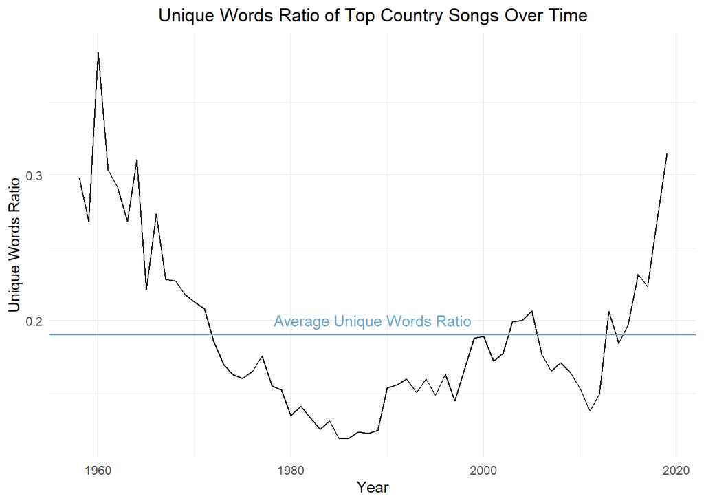

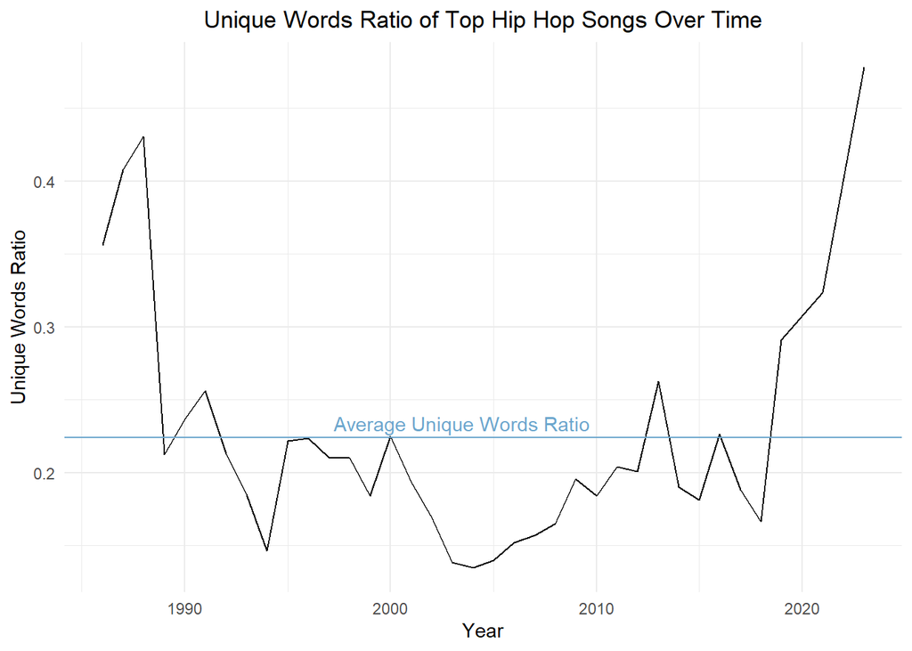

The unique words graph creates a line graph of the average ratio of unique words for each year in the inputted data set. The graph also includes a blue line which represents the overall unique word ratio from all the years. By including this blue line, we can reference when the ratio is above and below average. The unique word ratio represents how much diversity the words have within the lyrics. A low unique word ratio suggests a higher level of repetitiveness within the lyrics.

When looking at the Top Country data we see a high unique word ratio in the earlier years, especially around 1960 it peaks. A high ratio indicates that there are more unique words compared to overall words. Then the graph follows a downward trend and bottoms out around the mid to end 1980s. During this period, we see the most repetitive lyrics, and this could be due to the artists who have top songs. For example, where we see this low unique word ratio there are lots of songs by the band Alabama. Then we continue to see a low ratio in the 1990s and part of this could be because the artist Alan Jackson has multiple top songs within those years. Towards the end of the data, we see the ratio trend back upwards and this could be because Country music has been changing a lot and becoming more pop-like. Another reason could be that there are more artists with top songs throughout the more recent years.

## Measure of Repetitiveness: Title Repetition

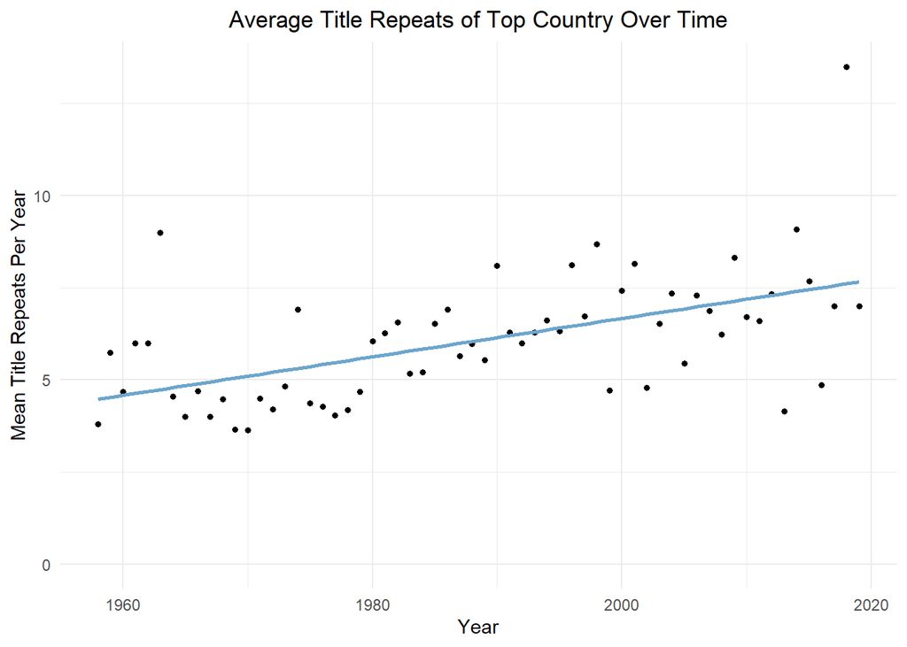

```
## [1] "R-squared value for Average Title Repeats of Top Country Over Time: 0.298873684989843"
```

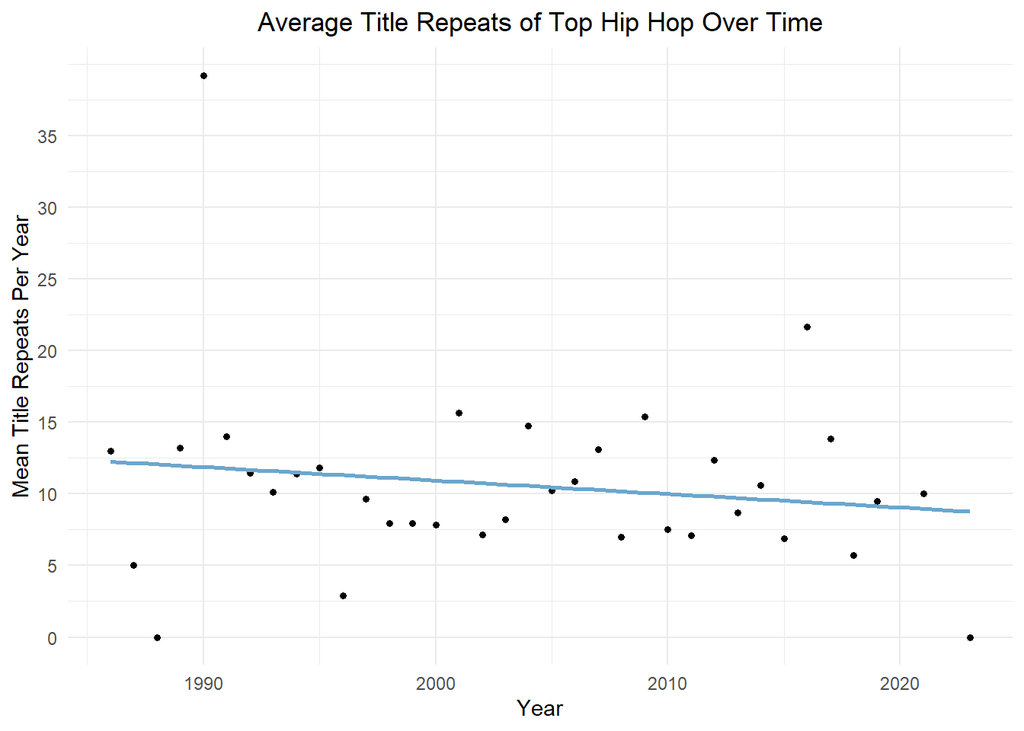

```
## [1] "R-squared value for Average Title Repeats of Top Hip Hop Over Time: 0.0237078959000397"
```

The figures above represent the average amount of times each title was repeated within its song lyrics per charting year. For country music we have data that can be visualized from 1958 to 2019. When looking at our plot for country, we can see an upward trend within the points, so we can say that over time song titles are increasingly being repeated in lyrics. We decided to fit a linear model to the data, and after observing the summary statistics we can see that the model fits moderately well with an R squared statistic of 0.2989. Time is explaining about 30% of the variance in title repetition.

Why are song titles being repeated more in Country and less in Hip Hop over time? One inference could be that country artists want to include the title of their songs in their music to enhance the listeners recall and remembrance of the song. Since the 1960s, the way musicians earn profit has changed, and artists may be focusing more on streams instead of selling records and cds. Another could be that over time the genre has shifted into more of a pop culture which is generally more repetitive. For Hip Hop, one inference could be that Hip Hop has grown in popularity over time and because of this, the genre has expanded in many ways. Hip Hop has developed into many sub genres and has become more diverse.

When comparing the two genres, we do have to keep in mind the fact that our collected country data has a sample size of 1466 that stretches over 61 years, while the Hip Hop genre has a sample size of 394, and only stretches 37 years of observation. Because our data for the country genre holds a larger sample size, we can see more of an accurate representation of trends within the genre. The sample size for Hip Hop is a lot smaller, and so our figures may not fully represent the genre.

## Proportion of Songs Containing Themes Across Genres

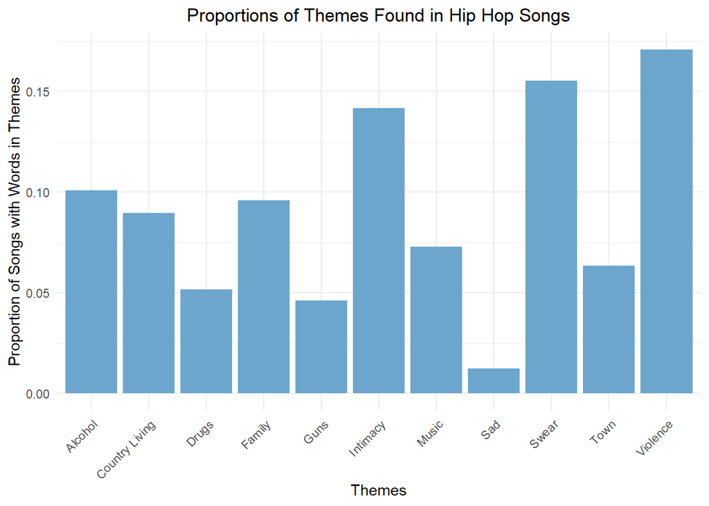

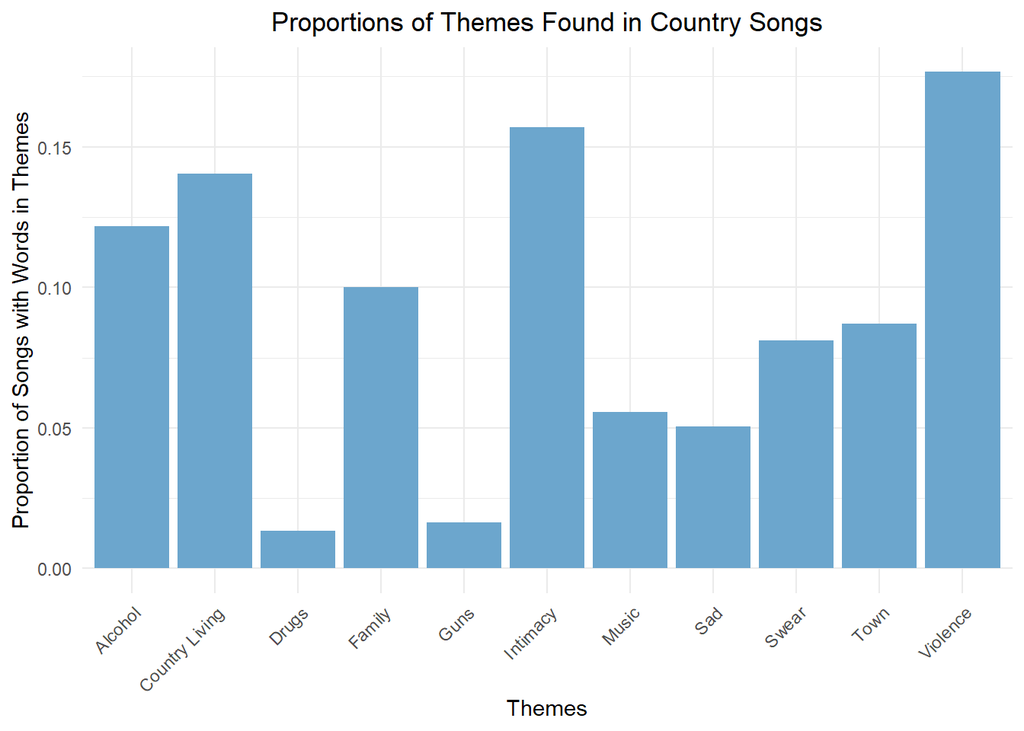

For our final analysis, we wanted to explore themes within song lyrics by tracking repetitiveness of certain words. Both Country music and Hip Hop have common stereotypes, and we wanted to see if these stereotypes are as apparent as they are thought to be. The themes that we looked for include words or short phrases relating to “Alcohol”, “Intimacy”, “Family”, “Drugs”, “Guns”, “Music”, “Sad”, “Country Living”, “Town”, “Swear”, and “Violence”. We chose these themes and words that we might think belong in them, so this analysis may be lacking certain words or phrases that others might think to include. Because of this these plots may not fully depict all possible themes or trends within them.

When looking at the bar graph for Country, we can see that words relating to Alcohol, Country Living, Intimacy, and Violence seem to be the most repetitive. The themes of Drugs and Guns are very low, and Family, Music, Sad, Swear, and Town are all pretty moderate trends.

When looking at the bar graph for Hip Hop, we can see that Intimacy, Swearing, and Violence are the most repetitive. Alcohol, Country Living, Drugs, Guns, and Town themes are all pretty moderately apparent, and the theme Sad appears the least according to our data collection.

Words relating to Drugs and Guns appear more frequently in Hip Hop than Country music, which is something that many people might have suspected, although their differences are not as drastic as some might think. One interesting observation is that for both Country music and Hip Hop, Violence seems to be the most repeated theme. Another is that in Country, the theme country living would be the most common theme many people would use to describe country music, and words of that theme are very present in the lyrics we have collected. For Hip Hop, many stereotypes for the genre would be relating to swearing, violence, sex, drugs, and guns and these are themes that are notible in our collection, but an interesting observation is that themes relating to Family appear more than drugs or guns.

When looking at the two plots we can see that for both Country and Hip Hop, there are certain themes that fit “stereo-typically” with the different genres that confirm these trends, although there are some surprising themes for both Country and Hip Hop found. Overall, I think that it is important not to oversimplify one genre based off of stereotypes that one might see.